# Testare gli assunti della regressione lineare e introdurre nuove variabili

# Regressione lineare semplice: testare gli assunti

Adesso andremo a verificare il rispetto degli assunti della regressione che abbiamo fatto tra la longevità degli animali, e la densità nell’anno della nascita. Sappiamo che il modello che abbiamo fittato è un oggetto complesso, che contiene molte informazioni. Possiamo ad esempio estrarre i residui del modello ed andare a verificare se sono verificate le condizioni per l’analisi che abbiamo appena effettuato.  
Dopo aver riletto e preparato i dati, e fittato il modello:

```r
mydata <- read_excel("data/CawRidge_LifetimeData.xlsx")
head(mydata)
mydata$densityYOB <- as.numeric(mydata$densityYOB)
mydata %>%
  dplyr::select(densityYOB, longevity, ALR) %>%
  mutate(repr = "yes") %>%
  na.omit() -> mydata
mydata$repr[mydata$ALR == "never"] <- "no"
mydata$repr <- as.factor(mydata$repr)
mydata %>%
  filter(repr == "yes") -> mydata_repr
mydata %>%
  filter(repr == "no") -> mydata_norepr
mod <- lm(longevity ~ densityYOB, data = mydata_repr)
```

possiamo proceere con l’estrazione dei residui e possiamo rappresentarli graficamente:

```r
residuals(mod)
```

```
          29           30           34           39           40           41           42           45           46           47
-0.006836956  0.672020624 -2.667408166 -0.667408166 -5.327979376 -2.667408166  1.332591834  1.860021390  0.860021390 -1.006836956
          48           49           50           51           52           53           54           55           56           57
-1.139978610 -2.139978610  0.029735785  3.993163044 -0.970264215 -5.970264215  3.860021390  3.029735785  2.029735785  2.029735785
          58           59           60           61           62           63           64           65           66           67
 2.793450562 -5.970264215 -6.206549438  1.793450562  1.793450562  0.860021390  1.199450180  2.199450180  1.029735785 -1.224835808
          68           69           70           71           72           73           74           75           76           77
 2.199450180  3.472308143 -0.527691857  2.472308143 -2.527691857  2.575451710  1.575451710 -0.527691857 -1.424548290 -3.527691857
          78           79           80           81           82           83           84           85           86           87
 2.575451710 -1.424548290 -4.169976697  2.472308143  1.472308143 -3.357977462  2.830023303  2.830023303  0.830023303  1.575451710
          88           89           90           91           92           93           94           95           96           97
 2.830023303  2.830023303  0.593738081  0.593738081 -1.406261919 -0.406261919  1.642022538 -1.406261919  3.593738081  1.593738081
          98           99          100          101          102          103          104          105          106          107
-3.406261919 -2.406261919 -1.406261919  2.018024068 -2.981975932  1.612024451 -0.981975932  0.612024451 -0.897118734 -2.897118734
         108          109          110          111          112          113
-0.897118734  0.612024451 -1.387975549 -1.387975549  0.612024451 -2.066833129
```

```r
par(mfrow=c(1,3))
hist(residuals(mod))
boxplot(residuals(mod))
```

```r
qqnorm(residuals(mod))
qqline(residuals(mod))
```

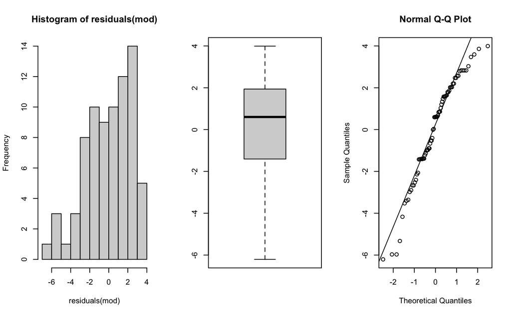

```r
par(mfrow=c(1,1))
```

In generale, il comando `plot` applicato al modello ci permette poi di ottenere tutti i plot diagnostici:

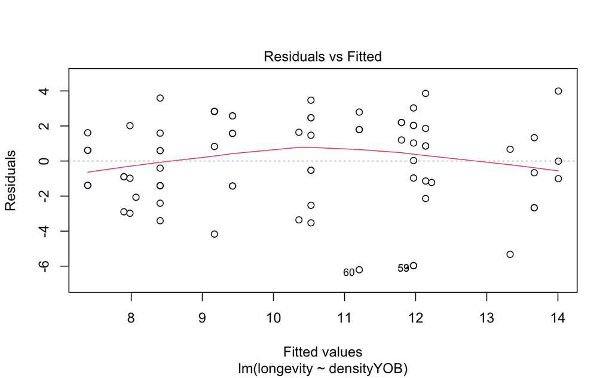

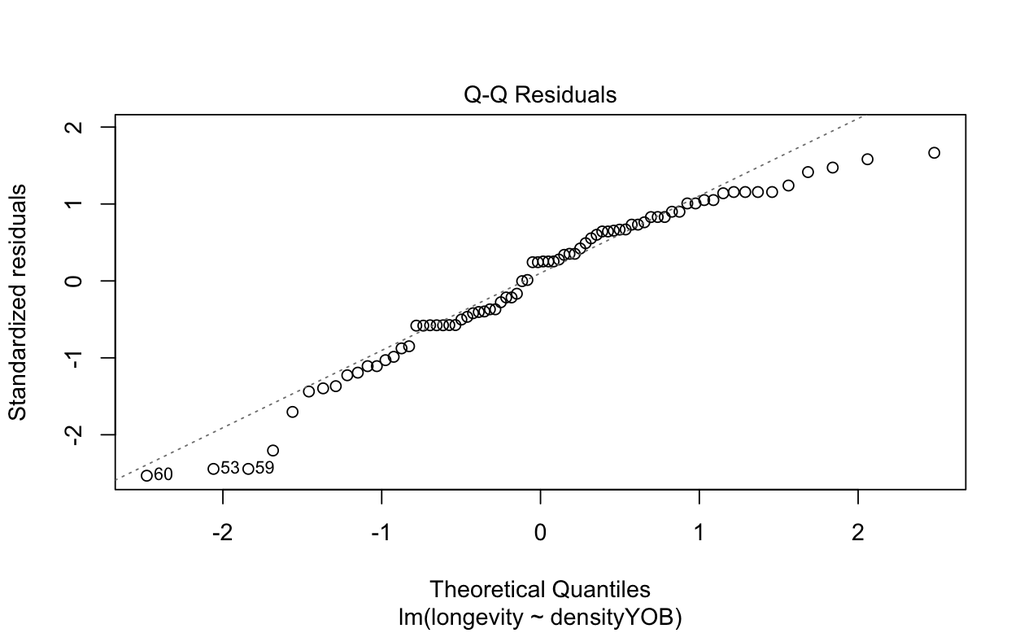

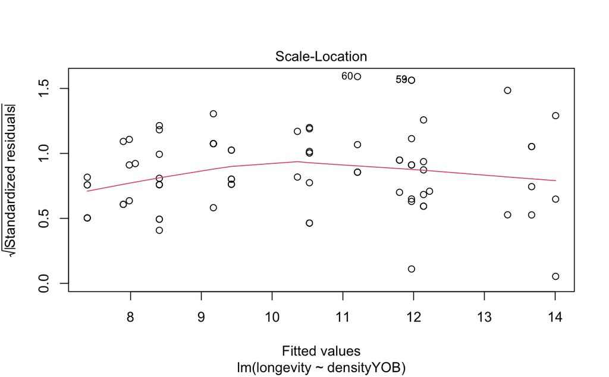

```r
plot(mod)
```

[figure not shown]

```r
NA
```

Dall’analisi dei plot, non sembrano esserci eccessive violazioni degli assunti. Tuttavia, notiamo che ci sono dei pattern nei residui e in particolare che questi non sono distribuiti normalmente. In effetti, la longevità è misurata in termini di numero di anni. Si tratta quindi di un **conteggio** del numero di anni, e questo implica che l’analisi può essere meglio condotta adottando un’altra distribuzione dei dati come riferimento, anziché una distribuzione normale.